# Classification - Exercise 2

Qunhang Li & Yanik Kipfer

*This question should be answered using the Weekly data set, which is part of the ISLR package. This data is similar in nature to the Smarket data from this chapters lab, except that it contains 1,089 weekly returns for 21 years, from the beginning of 1990 to the end of 2010.*

# Question A

**Produce some numerical and graphical summaries of the Weekly data. Do there appear to be any patterns?**

Through the result of the cor() function, there are Three pieces of information.

First, by looking at the summary statistics, we can deduce that the *Lag* and *Today* variables are quite similar to each other.

Second, the only substantial correlation pattern occurs between the year and volume variable. By plotting the two variables, we can see this relationship more directly. Volume is increasing over time, which means that the number of shares traded yearly increased from 1990 to 2010.

```r
# load data
library(ISLR)
library(ggplot2)

data <- data("Weekly")

# numerical summaries

  # summary of data
summary(Weekly)
```

```
##       Year           Lag1               Lag2               Lag3
##  Min.   :1990   Min.   :-18.1950   Min.   :-18.1950   Min.   :-18.1950
##  1st Qu.:1995   1st Qu.: -1.1540   1st Qu.: -1.1540   1st Qu.: -1.1580
##  Median :2000   Median :  0.2410   Median :  0.2410   Median :  0.2410
##  Mean   :2000   Mean   :  0.1506   Mean   :  0.1511   Mean   :  0.1472
##  3rd Qu.:2005   3rd Qu.:  1.4050   3rd Qu.:  1.4090   3rd Qu.:  1.4090
##  Max.   :2010   Max.   : 12.0260   Max.   : 12.0260   Max.   : 12.0260
##       Lag4               Lag5              Volume            Today
##  Min.   :-18.1950   Min.   :-18.1950   Min.   :0.08747   Min.   :-18.1950
##  1st Qu.: -1.1580   1st Qu.: -1.1660   1st Qu.:0.33202   1st Qu.: -1.1540
##  Median :  0.2380   Median :  0.2340   Median :1.00268   Median :  0.2410
##  Mean   :  0.1458   Mean   :  0.1399   Mean   :1.57462   Mean   :  0.1499
##  3rd Qu.:  1.4090   3rd Qu.:  1.4050   3rd Qu.:2.05373   3rd Qu.:  1.4050
##  Max.   : 12.0260   Max.   : 12.0260   Max.   :9.32821   Max.   : 12.0260
##  Direction
##  Down:484
##  Up  :605
##
##
##
##
```

```r
  # Correlation matrix.
cor(Weekly[,1:8])
```

```
##               Year         Lag1        Lag2        Lag3         Lag4
## Year    1.00000000 -0.032289274 -0.03339001 -0.03000649 -0.031127923
## Lag1   -0.03228927  1.000000000 -0.07485305  0.05863568 -0.071273876
## Lag2   -0.03339001 -0.074853051  1.00000000 -0.07572091  0.058381535
## Lag3   -0.03000649  0.058635682 -0.07572091  1.00000000 -0.075395865
## Lag4   -0.03112792 -0.071273876  0.05838153 -0.07539587  1.000000000
## Lag5   -0.03051910 -0.008183096 -0.07249948  0.06065717 -0.075675027
## Volume  0.84194162 -0.064951313 -0.08551314 -0.06928771 -0.061074617
## Today  -0.03245989 -0.075031842  0.05916672 -0.07124364 -0.007825873
##                Lag5      Volume        Today
## Year   -0.030519101  0.84194162 -0.032459894
## Lag1   -0.008183096 -0.06495131 -0.075031842
## Lag2   -0.072499482 -0.08551314  0.059166717
## Lag3    0.060657175 -0.06928771 -0.071243639
## Lag4   -0.075675027 -0.06107462 -0.007825873
## Lag5    1.000000000 -0.05851741  0.011012698
## Volume -0.058517414  1.00000000 -0.033077783
## Today   0.011012698 -0.03307778  1.000000000
```

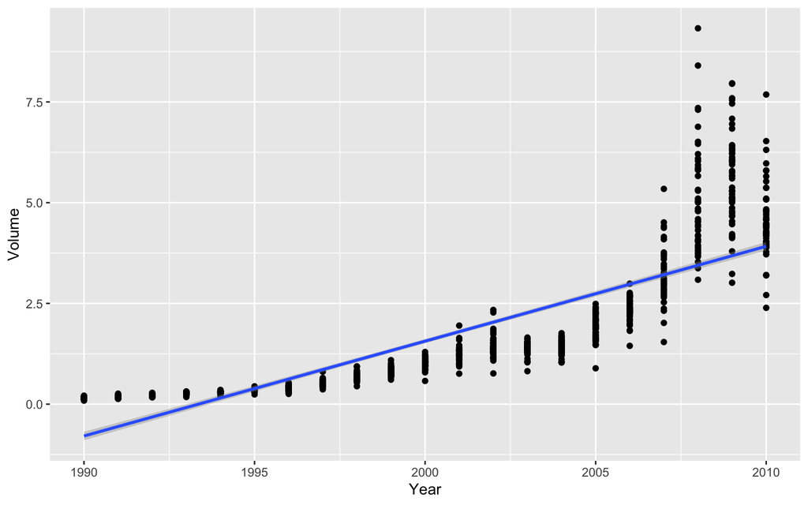

```r
# grafical summaries

  # plot scatter year - volume
ggplot(data=Weekly,mapping = aes(x = Year, y = Volume)) +
  geom_point() +
  geom_smooth(method = "lm")
```

Third, as the data is about the stock market, we would expect there to be some significant correlation between the percentage return today and the other factors. But it seems that this kind of correlation doesn’t exist.

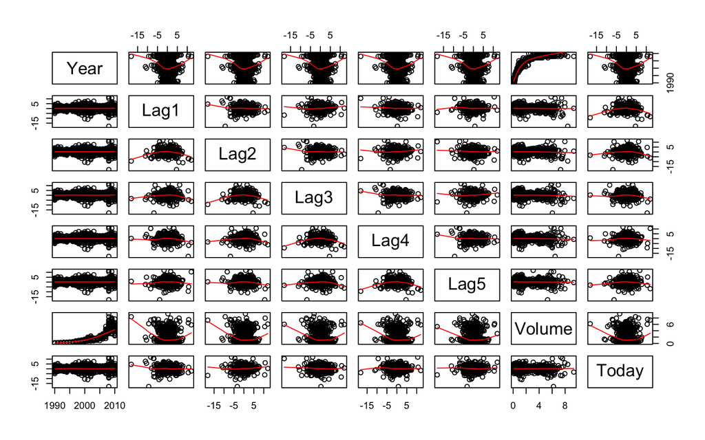

```r
  # Scatterplot matrix.
pairs(Weekly[,1:8],panel = panel.smooth)
```

# Question B

**Use the full data set to perform a logistic regression with Direction as the response and the five lag variables plus Volume as predictors. Use the summary function to print the results. Do any of the predictors appear to be statistically significant? If so, which ones?**

Yes, apart from the constant term, Lag2 is considered to be significant at 95% confidence interval.

```r
# run logistic regression
logistic_fit = glm(Direction ~ Lag1+Lag2+Lag3+Lag4+Lag5+Volume,
                   data=Weekly,
                   family=binomial)

# output results
summary(logistic_fit)
```

```
##
## Call:
## glm(formula = Direction ~ Lag1 + Lag2 + Lag3 + Lag4 + Lag5 +
##     Volume, family = binomial, data = Weekly)
##
## Deviance Residuals:
##     Min       1Q   Median       3Q      Max
## -1.6949  -1.2565   0.9913   1.0849   1.4579
##
## Coefficients:
##             Estimate Std. Error z value Pr(>|z|)
## (Intercept)  0.26686    0.08593   3.106   0.0019 **
## Lag1        -0.04127    0.02641  -1.563   0.1181
## Lag2         0.05844    0.02686   2.175   0.0296 *
## Lag3        -0.01606    0.02666  -0.602   0.5469
## Lag4        -0.02779    0.02646  -1.050   0.2937
## Lag5        -0.01447    0.02638  -0.549   0.5833
## Volume      -0.02274    0.03690  -0.616   0.5377
## ---
## Signif. codes:  0 '***' 0.001 '**' 0.01 '*' 0.05 '.' 0.1 ' ' 1
##
## (Dispersion parameter for binomial family taken to be 1)
##
##     Null deviance: 1496.2  on 1088  degrees of freedom
## Residual deviance: 1486.4  on 1082  degrees of freedom
## AIC: 1500.4
##
## Number of Fisher Scoring iterations: 4
```

# Question C

**Compute the confusion matrix and overall fraction of correct predictions. Explain what the confusion matrix is telling you about the types of mistakes made by logistic regression.**

With the help of the confusion matrix, we find the overall fraction of correct predictions to be 56.1%.

```r
attach(Weekly)

# predict model
logistic_probs = predict(logistic_fit, type="response")

# The type="response" option tells R to output probabilities of the form P(Y = 1|X). contrasts() function indicates that R has created a dummy variable with a 1 for Up.
contrasts(Direction)
```

```
##      Up
## Down  0
## Up    1
```

```r
# create vector with prediction outputs
logistic_preds = rep("Down", 1089) # Vector of 1089 "Down" elements.
logistic_preds[logistic_probs>0.5] = "Up" # Change "Down" to up when probability > 0.5.

# Create confusion matrix
conf = table(logistic_preds,Direction)
table(logistic_preds,Direction)
```

```
##               Direction
## logistic_preds Down  Up
##           Down   54  48
##           Up    430 557
```

```r
# Accuracy: diagonal elements of the confusion matrix indicate correct predictions, while the off-diagonals represent incorrect predictions. mean() function can be used to compute the fraction of days for which the prediction was correct
mean(logistic_preds == Direction)
```

```
## [1] 0.5610652
```

```r
# or by hand
sum(diag(as.matrix(conf)))/nrow(Weekly)
```

```
## [1] 0.5610652
```

At the first glance it seems good, as the error rate is 43.9%, which is lower than 50%, the random rate. But we should not forget that this is just the training error rate, and the testing error rate is usually higher than the training one.

So we divide the data into two parts, the data from 1990 to 2008 we use as a training set and the data from 2009 to 2010 as testing set. The results are disappointing. The testing error rate is 53.9%, which is higher than 50%, thus, this model doesn’t reduce the error rate at all.

A reason for the low performance might be that too many insignificant variables are included, which might cause this high error rate. Because they are insignificance this means that the information they provide contains too much noise. This inflates the variance of the model while the bias doesn’t reduce in the meantime. So a reasonable plan is kick the insignificant variables out of the model.

```r
# Check the testing error rate
# Training observations from 1990 to 2008.
train = (Year<2009)

# Test observations from 2009 to 2010.
Test = Weekly[!train ,]
Test_Direction= Direction[!train]

# Logistic regression on training set.
logistic_fit2 = glm(Direction ~ Lag1+Lag2+Lag3+Lag4+Lag5+Volume,
                    data=Weekly,
                    family=binomial, subset=train)

# Predictions on the test set.
logistic_probs2 = predict(logistic_fit2,Test, type="response")
logistic_preds2 = rep("Down", 104)
logistic_preds2[logistic_probs2>0.5] = "Up"

# Confusion matrix.
table(logistic_preds2,Test_Direction)
```

```
##                Test_Direction
## logistic_preds2 Down Up
##            Down   31 44
##            Up     12 17
```

```r
# Accuracy
mean(logistic_preds2 == Test_Direction)
```

```
## [1] 0.4615385
```

# Question D

**Now fit the logistic regression model using a training data period from 1990 to 2008, with Lag2 as the only predictor. Compute the confusion matrix and the overall fraction of correct predictions for the held out data (that is, the data from 2009 and 2010).**

After adjusting the model, the accuracy increases, which means the testing error rate was reduced. So the conjecture about the mistake made in (c) is correct.

```r
# Training observations from 1990 to 2008.
train = (Year<2009)

# Test observations from 2009 to 2010.
Test = Weekly[!train ,]
Test_Direction= Direction[!train]

# Logistic regression on training set.
logistic_fit3 = glm(Direction ~ Lag2,
                    data=Weekly,
                    family=binomial,
                    subset=train)

# Predictions on the test set.
logistic_probs3 = predict(logistic_fit3,Test, type="response")
logistic_preds3 = rep("Down", 104)
logistic_preds3[logistic_probs3>0.5] = "Up"

# Confusion matrix.
table(logistic_preds3,Test_Direction)
```

```
##                Test_Direction
## logistic_preds3 Down Up
##            Down    9  5
##            Up     34 56
```

```r
# Accuracy
mean(logistic_preds3 == Test_Direction)
```

```
## [1] 0.625
```

# Question E

**Next Repeat (c) and (d) using a Linear Probability Model. Compare the models**

The results are almost the same.

```r
#b.2
#create a numeric variable
Weekly$Direction_num = rep(0, 1089) # Vector of 1089 "0" elements.
Weekly$Direction_num[Weekly$Direction=="Up"] = 1 # Change "1" to up when direction is up.

# run logistic regression
logistic_fit_lpm = lm(Direction_num ~ Lag1+Lag2+Lag3+Lag4+Lag5+Volume,
                      data=Weekly)
# output results
summary(logistic_fit_lpm)
```

```
##
## Call:
## lm(formula = Direction_num ~ Lag1 + Lag2 + Lag3 + Lag4 + Lag5 +
##     Volume, data = Weekly)
##
## Residuals:
##     Min      1Q  Median      3Q     Max
## -0.7793 -0.5456  0.3891  0.4454  0.6527
##
## Coefficients:
##              Estimate Std. Error t value Pr(>|t|)
## (Intercept)  0.565983   0.021078  26.852   <2e-16 ***
## Lag1        -0.010042   0.006442  -1.559   0.1194
## Lag2         0.014086   0.006469   2.177   0.0297 *
## Lag3        -0.003752   0.006442  -0.582   0.5604
## Lag4        -0.006655   0.006447  -1.032   0.3021
## Lag5        -0.003404   0.006429  -0.529   0.5966
## Volume      -0.005744   0.009041  -0.635   0.5254
## ---
## Signif. codes:  0 '***' 0.001 '**' 0.01 '*' 0.05 '.' 0.1 ' ' 1
##
## Residual standard error: 0.4963 on 1082 degrees of freedom
## Multiple R-squared:  0.008938,   Adjusted R-squared:  0.003442
## F-statistic: 1.626 on 6 and 1082 DF,  p-value: 0.1364
```

```r
#c.2
attach(Weekly)

# predict model
logistic_probs_lpm = predict(logistic_fit_lpm, type="response")

# The type="response" option tells R to output probabilities of the form P(Y = 1|X). contrasts() function indicates that R has created a dummy variable with a 1 for Up.
contrasts(Direction)
```

```
##      Up
## Down  0
## Up    1
```

```r
# create vector with prediction outputs
logistic_preds_lpm = rep("Down", 1089) # Vector of 1089 "Down" elements.
logistic_preds_lpm[logistic_probs_lpm>0.5] = "Up" # Change "Down" to up when probability > 0.5.

# Create confusion matrix
conf = table(logistic_preds_lpm,Direction)
table(logistic_preds_lpm,Direction)
```

```
##                   Direction
## logistic_preds_lpm Down  Up
##               Down   52  44
##               Up    432 561
```

```r
# Accuracy: diagonal elements of the confusion matrix indicate correct predictions, while the off-diagonals represent incorrect predictions. mean() function can be used to compute the fraction of days for which the prediction was correct
mean(logistic_preds_lpm == Direction)
```

```
## [1] 0.5629017
```

```r
# Check the testing error rate

# Logistic regression on training set.
logistic_fit2_lpm = glm(Direction_num~Lag1+Lag2+Lag3+Lag4+Lag5+Volume,
                        data=Weekly,
                        family=binomial,
                        subset=train)

# Predictions on the test set.
logistic_probs2_lpm = predict(logistic_fit2_lpm,Test, type="response")
logistic_preds2_lpm = rep("Down", 104)
logistic_preds2_lpm[logistic_probs2_lpm>0.5] = "Up"

# Confusion matrix.
table(logistic_preds2_lpm,Test_Direction)
```

```
##                    Test_Direction
## logistic_preds2_lpm Down Up
##                Down   31 44
##                Up     12 17
```

```r
# Accuracy
mean(logistic_preds2_lpm == Test_Direction)
```

```
## [1] 0.4615385
```

```r
##d.2

# Logistic regression on training set.
logistic_fit3_lpm = lm(Direction_num ~ Lag2,
                       data=Weekly,
                       subset=train)

# Predictions on the test set.
logistic_probs3_lpm = predict(logistic_fit3_lpm,Test, type="response")
logistic_preds3_lpm = rep("Down", 104)
logistic_preds3_lpm[logistic_probs3_lpm>0.5] = "Up"

# Confusion matrix.
table(logistic_preds3_lpm,Test_Direction)
```

```
##                    Test_Direction
## logistic_preds3_lpm Down Up
##                Down    9  5
##                Up     34 56
```

```r
# Accuracy
mean(logistic_preds3_lpm == Test_Direction)
```

```
## [1] 0.625
```